# act_report

## Report: act_report

- Create a **250-word-minimum written report** called "act_report.pdf" or "act_report.html" that communicates the insights and displays the visualization(s) produced from your wrangled data. This is to be framed as an external document, like a blog post or magazine article, for example.

### INSIGHTS FROM WRANGLED DATA

> After wrangling the three pieces of data and then analysing the wrangled data, I came up with up to five insights. These insights are itemised below:

#### 1.) The top five (5) most common ratings are on a scale of 9/10 to 13/10

> The rating system set the denominator to 10 but provided an allowance for the numerator to go beyond 10. From the analysis, I observed that the top five (5) most common ratings fell between 9/10 and 13/10. This suggests that several reviewers were very pleased with the different breeds they saw.

> **2.) After the first prediction, the top ten (10) most predicted dogs are:**
> 1. golden_retriever
> 2. Labrador_retriever
> 3. Pembroke
> 4. Chihuahua
> 5. pug
> 6. chow
> 7. Samoyed
> 8. Pomeranian
> 9. toy_poodle
> 10. malamute

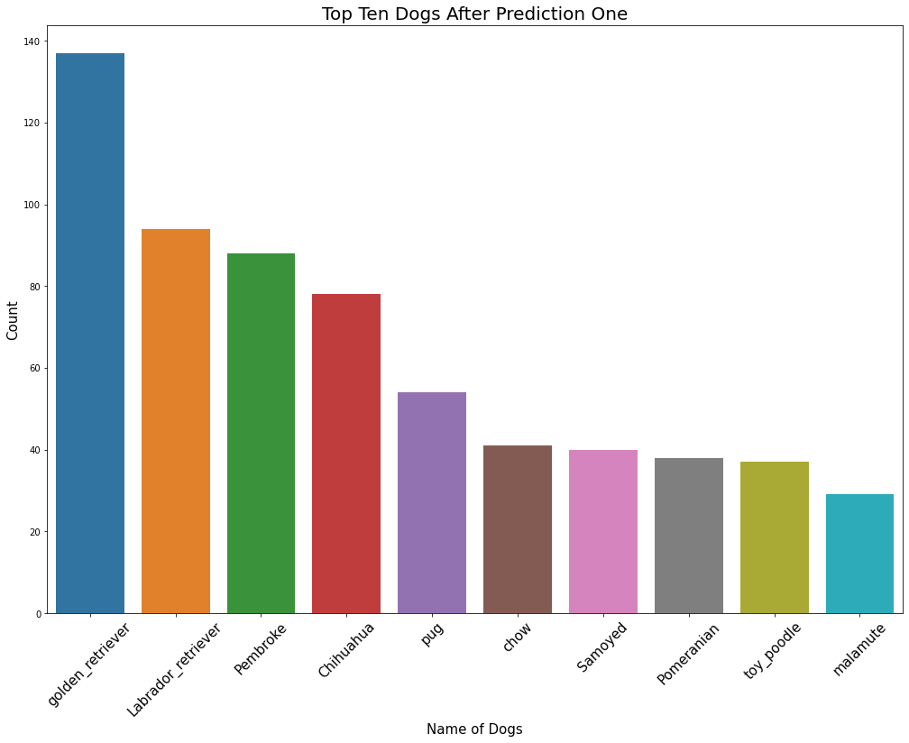

> **3.) After the second prediction, the top ten (10) most predicted dogs are:**
> 1. Labrador_retriever
> 2. golden_retriever
> 3. Cardigan
> 4. Chihuahua
> 5. Chesapeake_Bay_retriever
> 6. French_bulldog
> 7. Pomeranian
> 8. toy_poodle
> 9. Siberian_husky
> 10. cocker_spaniel

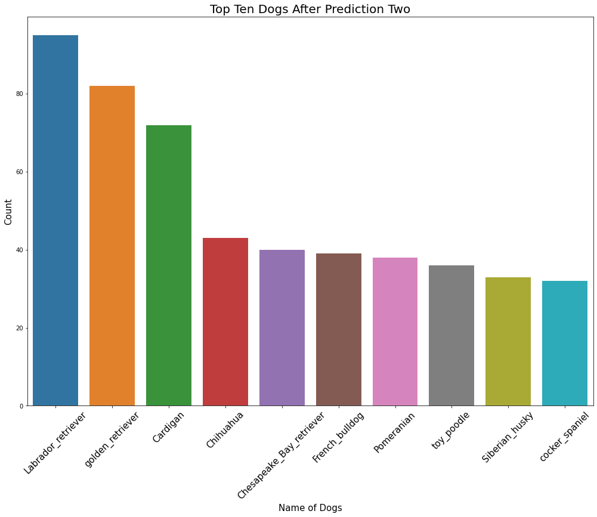

> **4.) After the third prediction, the top ten (10) most predicted dogs are:**
> 1. Labrador_retriever
> 2. Chihuahua
> 3. golden_retriever
> 4. Eskimo_dog
> 5. kelpie
> 6. kuvasz
> 7. chow
> 8. Pomeranian
> 9. cocker_spaniel
> 10. toy_poodle

[figure not shown]

#### 5.) Correlation between the retweet count & favourite count.

> The analysis showed there’s a correlation between the retweet count & the favourite count. The correlation value is 0.913284. This is a strong positive correlation that indicates a linear relationship between retweet count & favourite count.

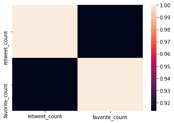

> **REFERENCES:**
> - [Stackoverflow](https://stackoverflow.com/)
> - [Kaggle](https://www.kaggle.com/code/pulleyba/project-data-wrangling/notebook)
> - [Github 1](https://github.com/divyanitin/TwitterDataAnalysis-WeRateDogs/blob/master/wrangle_act.ipynb)
> - [Github 2](https://github.com/Mitul2991/Udacity-Project---Wrangling-and-analyzing-data-from-twitter-archives/blob/master/wrangle_act.ipynb)
> - [Github 3](https://github.com/lejimmy/udacity-twitter-weratedogs-analysis/blob/master/wrangle_act.ipynb)